# Democracy and Development

Carolina Torreblanca

University of Pennsylvania

**Global Development**: Intermediate Topics in Politics, Policy, and Data

PSCI 3200 - Spring 2026

## Agenda

- Democracy as a consequence of development
- Democracy as a cause of development
- Fixed effects

## Democracy and Development

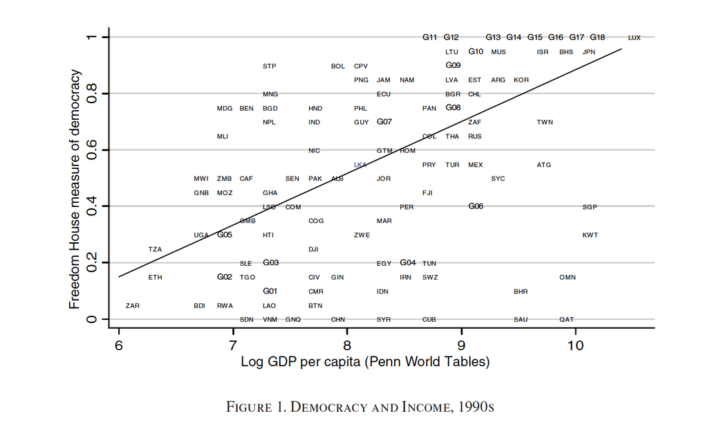

From Acemoglu et. al. 2008

## Two explanations

1. Direct causal link
   - Development $\rightarrow$ democracy
   - Democracy $\rightarrow$ development
2. Indirect link or correlation
   - Income $\rightarrow$ regime survival
   - Omitted variable

# Development as cause

## Modernization Theory, Lipset (1960)

**Development causes democracy**

- Economic development requires investing in education, infrastructure, urbanization…
  - Modernizing.
- Modernization triggers changes making democracy more likely
  - Society becomes more complex and organized
  - Education facilitates democratic citizenship
  - Infrastructure and urbanization facilitate political competition

## The Threat of Revolution

- [Acemoglu and Robinson (2001)](https://www.aeaweb.org/articles?id=10.1257/aer.91.4.938)
- Rich elites control autocratic societies
  - But they fear revolution!
- How to prevent it?
  - Democratize and redistribute some of the resources
- Elites and non-elites are better off

# Development as consequence

## Democracy Spurs Development

Dictatorship, Democracy, and Development [(Olson, 1993)](https://www.jstor.org/stable/2938736?seq=5)

- Autocrats want a wealthy country.
- Why would citizens produce wealth if it can be expropriated by an autocrat?
  - Solution: **Credibly** tie your own hands with democratic institutions
- By sharing political power and enshrining property rights, create incentives to produce wealth
- Democracy $\rightarrow$ development

# Other Explanations

## Democratic Survival

- Democracy is established independently of development …
- But development helps democracies survive
- “The more well-to-do a nation, the greater the chances it will sustain democracy” (Lipset, 1959)
- Empirical implications: There will be a correlation btw democracy and development even if development does not cause democracy!

## Democracy and Development in Research

- Are the theoretical arguments for $Democracy \rightarrow Development$ convincing?
- Are the theoretical arguments for $Development \rightarrow Democracy$ convincing?

## Democracy and Development in Research

- [Paglayan, 2020](https://www.cambridge.org/core/journals/american-political-science-review/article/nondemocratic-roots-of-mass-education-evidence-from-200-years/8C8C594AA07996A00ED4BEFC66B133B7)
  - Reconsiders whether democratization increases the provision of education. Finds that democratization *can* increase education provision, but that education is also a powerful for autocrats
- [Fujiwara, 2015](https://www.cambridge.org/core/journals/american-political-science-review/article/nondemocratic-roots-of-mass-education-evidence-from-200-years/8C8C594AA07996A00ED4BEFC66B133B7)
  - Electronic voting in Brazil reduced mistakes when voting from poorest, resulting in better accountability and more spending in health care

## Democracy and Development in Research

- [Ferraz and Finan, 2008](https://academic.oup.com/qje/article/123/2/703/1930865)
  - Random audits of Brazilian majors reduces the chances that corrupt politicians are re-elected
- [Mori, et. al., 2024](https://www.journals.uchicago.edu/doi/10.1086/727799)
  - Use gender quotas to examine if female politicians use local budget more or less effectively
- [Pailler, 2018](https://www.sciencedirect.com/science/article/pii/S0095069616301577?casa_token=lxyQWsb-OwEAAAAA:_UixyIjFcdpfLphKULMOGM-1IhqRDTooRDDUTqx5n6SrEAwKe3NS0hnMVNxaNQ_qL-Ho4L2hEi4)
  - Democratic competition increases deforestation!

## That Correlation Again

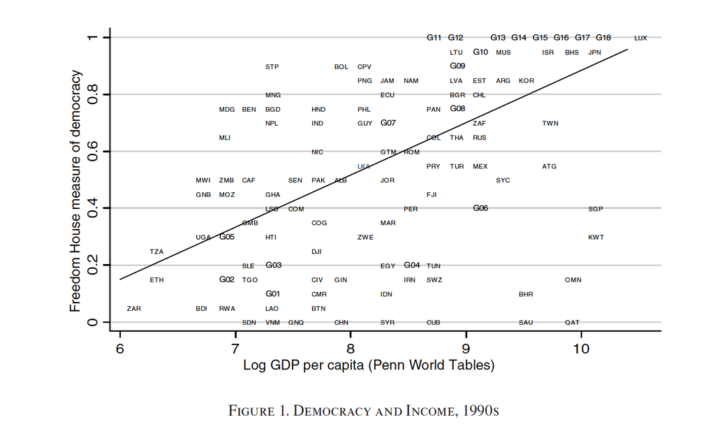

From Acemoglu et. al. 2008

## Acemoglu et. al. 2008

- The criticism: correlation of democracy and development does not mean causation
- Alternative: countries embark on divergent development paths
- Empirical implication: observed association is correlational

## Which is the correct DAG?

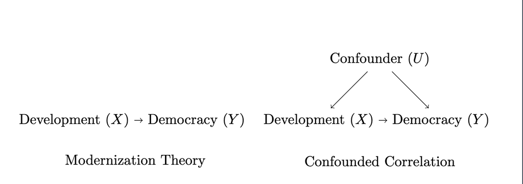

## The Problem

- If the confounded DAG is correct, we need to control for U
- What U do the authors propose?

> *“The major source of potential bias in a regression of democracy on income per capita is country-specific, historical factors influencing both political and economic development.”*
- Cannot control for all historical factors individually. So what do we do?

# Fixed Effects

## Strategy 1: Fixed Effects

> *“We utilize two strategies to investigate the causal effect of income on democracy. Our first strategy is to control for country-specific factors affecting both income and democracy by including country fixed effects”*

## From Between to Within

- The standard regression compares rich countries to poor countries (*between* variation)

## Why Does This Matter? Simpson’s Paradox

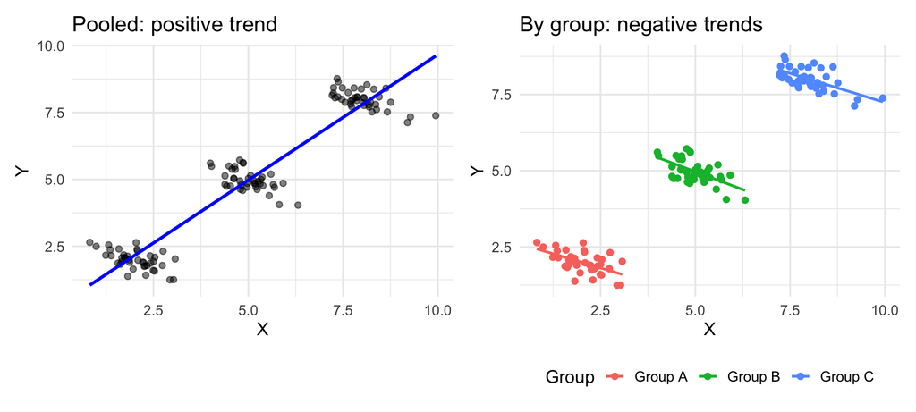